# GEO880 - CMA: Exercise 2

Gregory Biland

5/3/2022

## Taks 1

## Task 2

```
## Simple feature collection with 51246 features and 7 fields
## Geometry type: POINT
## Dimension:     XY
## Bounding box:  xmin: 2568153 ymin: 1202306 xmax: 2575154 ymax: 1207609
## Projected CRS: CH1903+ / LV95
## # A tibble: 51,246 × 8
## # Groups:   TierID [3]
##    TierID TierName CollarID DatetimeUTC                E        N
##  * <chr>  <chr>       <dbl> <dttm>                 <dbl>    <dbl>
##  1 002A   Sabi        12275 2014-08-22 21:00:12 2570409. 1204752.
##  2 002A   Sabi        12275 2014-08-22 21:15:16 2570402. 1204863.
##  3 002A   Sabi        12275 2014-08-22 21:30:43 2570394. 1204826.
##  4 002A   Sabi        12275 2014-08-22 21:46:07 2570379. 1204817.
##  5 002A   Sabi        12275 2014-08-22 22:00:22 2570390. 1204818.
##  6 002A   Sabi        12275 2014-08-22 22:15:10 2570390. 1204825.
##  7 002A   Sabi        12275 2014-08-22 22:30:13 2570387. 1204831.
##  8 002A   Sabi        12275 2014-08-22 22:45:11 2570381. 1204840.
##  9 002A   Sabi        12275 2014-08-22 23:00:27 2570316. 1204935.
## 10 002A   Sabi        12275 2014-08-22 23:15:41 2570393. 1204815.
## # … with 51,236 more rows, and 2 more variables: geometry <POINT [m]>,
## #   timelag <int>
```

```
## Simple feature collection with 3 features and 2 fields
## Geometry type: MULTIPOINT
## Dimension:     XY
## Bounding box:  xmin: 2568153 ymin: 1202306 xmax: 2575154 ymax: 1207609
## Projected CRS: CH1903+ / LV95
## # A tibble: 3 × 3
##   TierID mean_timelag                                                   geometry
##   <chr>         <dbl>                                           <MULTIPOINT [m]>
## 1 002A          1286. ((2568903 1206200), (2568925 1206207), (2568980 1206197),…
## 2 016A          1412. ((2569231 1205823), (2569245 1205925), (2569247 1206027),…
## 3 018A          1599. ((2568153 1205611), (2568155 1205613), (2568161 1205624),…
```

```
##    Min. 1st Qu.  Median    Mean 3rd Qu.    Max.    NA's
##      12     896     903    1408     916   60367       3
```

For how long were the individual tracked? Are there gaps? Were all individuals tracked concurrently or sequentially? What is the temporal sampling interval between the locations?

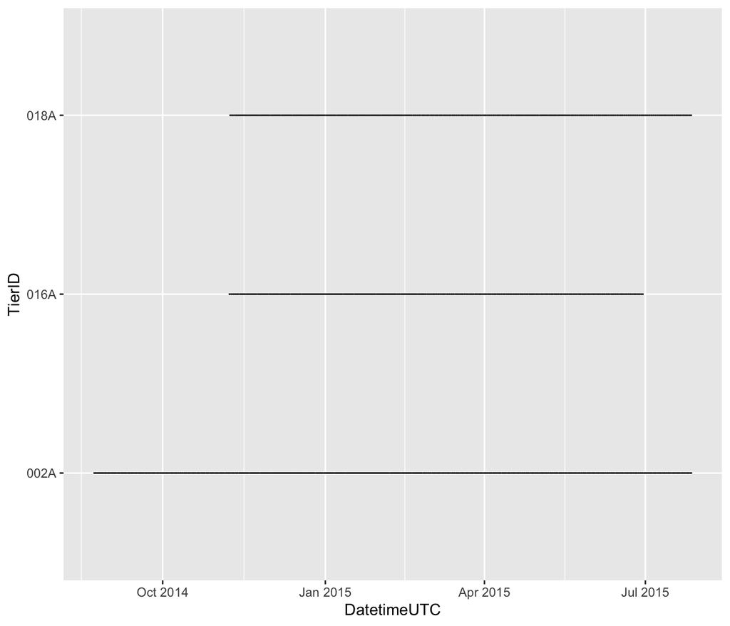

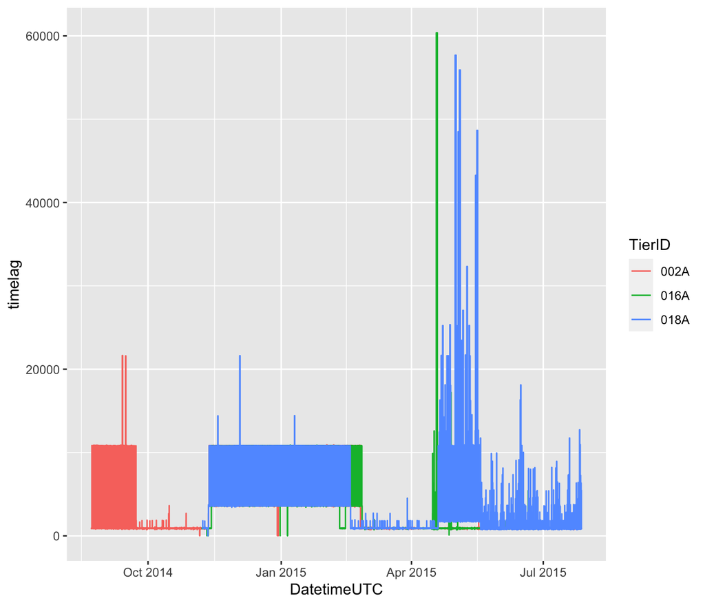

## Task 3

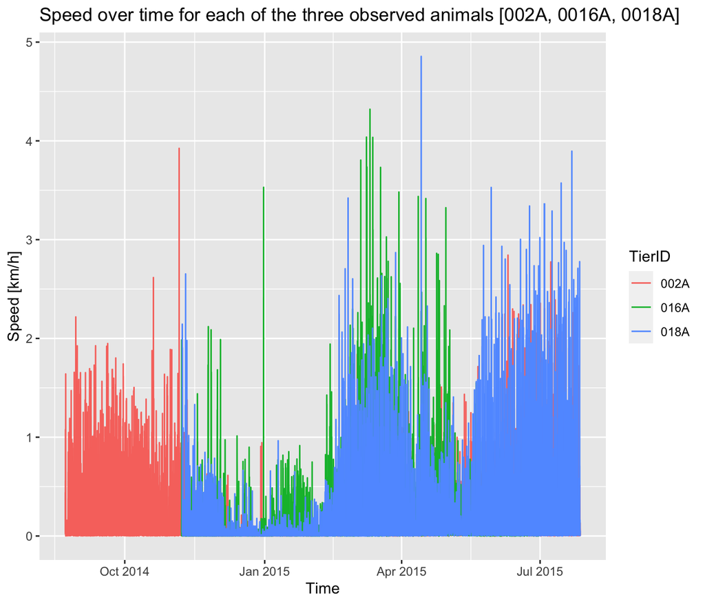

```
## Simple feature collection with 3 features and 2 fields
## Geometry type: MULTIPOINT
## Dimension:     XY
## Bounding box:  xmin: 2568153 ymin: 1202306 xmax: 2575154 ymax: 1207609
## Projected CRS: CH1903+ / LV95
## # A tibble: 3 × 3
##   TierID mean_speed                                                     geometry
##   <chr>       <dbl>                                             <MULTIPOINT [m]>
## 1 002A        0.133 ((2568903 1206200), (2568925 1206207), (2568980 1206197), (…
## 2 016A        0.132 ((2569231 1205823), (2569245 1205925), (2569247 1206027), (…
## 3 018A        0.181 ((2568153 1205611), (2568155 1205613), (2568161 1205624), (…
```

The unit in which the speed is returned would be m/s, but can be changed to km/h, by multiplying by 3.6. An essential issue with the speed calculations it that it is greatly dependent on the output of the timelag value. As it is not always the same unit, so sometimes seconds and sometimes minutes, before the speed calculations the unit of the values have to be checked.

## Task 4

```
## # A tibble: 1 × 2
##   TierID mean_timelag
##   <chr>         <dbl>
## 1 010C             60
```

```
## # A tibble: 1 × 2
##   TierID mean_speed
##   <chr>       <dbl>
## 1 010C        0.295
```

```
## # A tibble: 1 × 2
##   TierID mean_timelag
##   <chr>         <dbl>
## 1 010C            180
```

```
## # A tibble: 1 × 2
##   TierID mean_speed
##   <chr>       <dbl>
## 1 010C        0.195
```

```
## # A tibble: 1 × 2
##   TierID mean_timelag
##   <chr>         <dbl>
## 1 010C            360
```

```
## # A tibble: 1 × 2
##   TierID mean_speed
##   <chr>       <dbl>
## 1 010C        0.157
```

```
## # A tibble: 1 × 2
##   TierID mean_timelag
##   <chr>         <dbl>
## 1 010C            540
```

```
## # A tibble: 1 × 2
##   TierID mean_speed
##   <chr>       <dbl>
## 1 010C        0.129
```

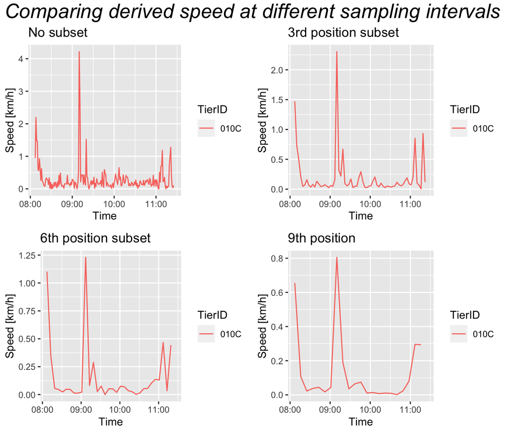

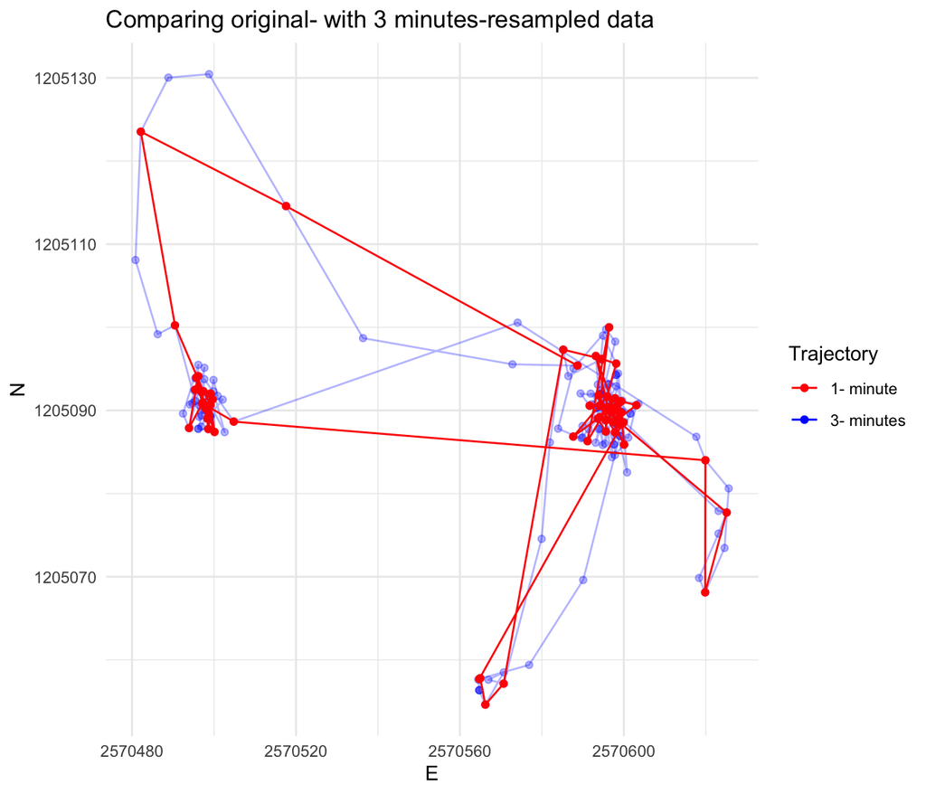

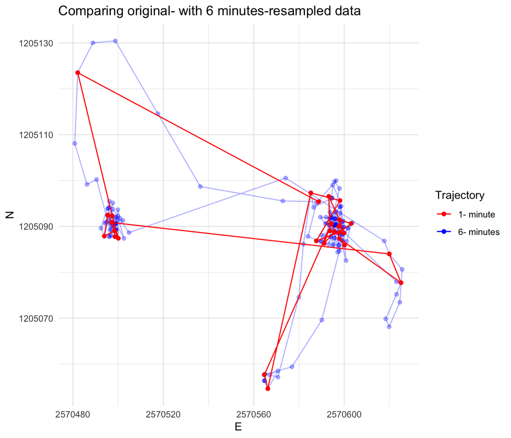

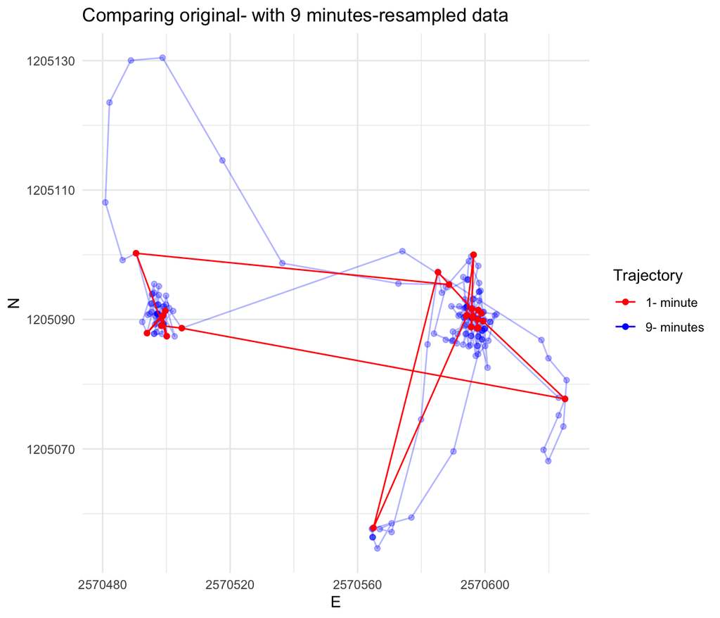

In terms of velocities, it is clear to see how the temporal accuracy changes when the points are removed from the data set. Thus, in the original data set, every small velocity is still visible, while up to the subset with every 9th position, the curve is almost completely smoothed, as 90% of the values are missing. Basically, the global trends can still be read out in the 3 reduced plots. The more detailed trends are asked, the more difficult this becomes. Thus, with the complete data set, minutely trends can still be shown, whereas with the last plot, it is only possible to recognize hourly trends and information.

The same is with the motion paths. The fewer data points, the more the path is simplified and less meaningful in detail.

## Task 5

```
##      value
##  Min.   :0.03982
##  1st Qu.:0.14113
##  Median :0.20108
##  Mean   :0.29058
##  3rd Qu.:0.27017
##  Max.   :2.49584
##  NA's   :3
```

```
##      value
##  Min.   :0.04924
##  1st Qu.:0.14488
##  Median :0.19829
##  Mean   :0.28772
##  3rd Qu.:0.29052
##  Max.   :1.92571
##  NA's   :4
```

```
##      value
##  Min.   :0.05567
##  1st Qu.:0.15297
##  Median :0.19754
##  Mean   :0.28466
##  3rd Qu.:0.29533
##  Max.   :1.62000
##  NA's   :5
```

```
##      value
##  Min.   :0.06918
##  1st Qu.:0.15909
##  Median :0.19756
##  Mean   :0.28148
##  3rd Qu.:0.29816
##  Max.   :1.42237
##  NA's   :6
```

[figure not shown]